# Risk Factor Analysis

## Outcome Variable

**Outcome Variable:** ever_stunted

## Predictor Variables

**Intervention Variable:** birthwt

**Adjustment Set:**

- arm
- W_mage
- meducyrs
- feducyrs
- vagbrth
- single
- brthmon
- W_parity
- delta_W_mage
- delta_meducyrs
- delta_feducyrs
- delta_vagbrth
- delta_single
- delta_brthmon
- delta_W_parity

## Stratifying Variables

The analysis was stratified on these variable(s):

- agecat
- studyid
- country

## Data Summary

| agecat | studyid | country | birthwt | ever_stunted | n_cell | n |
| --- | --- | --- | --- | --- | --- | --- |
| 0-24 months (no birth st.) | CMC-V-BCS-2002 | INDIA | Normal or high birthweight | 0 | 27 | 290 |
| 0-24 months (no birth st.) | CMC-V-BCS-2002 | INDIA | Normal or high birthweight | 1 | 249 | 290 |
| 0-24 months (no birth st.) | CMC-V-BCS-2002 | INDIA | Low birthweight | 0 | 1 | 290 |
| 0-24 months (no birth st.) | CMC-V-BCS-2002 | INDIA | Low birthweight | 1 | 13 | 290 |
| 0-24 months (no birth st.) | CMIN | BANGLADESH | Normal or high birthweight | 0 | 7 | 17 |
| 0-24 months (no birth st.) | CMIN | BANGLADESH | Normal or high birthweight | 1 | 6 | 17 |
| 0-24 months (no birth st.) | CMIN | BANGLADESH | Low birthweight | 0 | 3 | 17 |
| 0-24 months (no birth st.) | CMIN | BANGLADESH | Low birthweight | 1 | 1 | 17 |
| 0-24 months (no birth st.) | COHORTS | GUATEMALA | Normal or high birthweight | 0 | 232 | 833 |
| 0-24 months (no birth st.) | COHORTS | GUATEMALA | Normal or high birthweight | 1 | 555 | 833 |
| 0-24 months (no birth st.) | COHORTS | GUATEMALA | Low birthweight | 0 | 6 | 833 |
| 0-24 months (no birth st.) | COHORTS | GUATEMALA | Low birthweight | 1 | 40 | 833 |
| 0-24 months (no birth st.) | COHORTS | INDIA | Normal or high birthweight | 0 | 3828 | 5963 |
| 0-24 months (no birth st.) | COHORTS | INDIA | Normal or high birthweight | 1 | 1337 | 5963 |
| 0-24 months (no birth st.) | COHORTS | INDIA | Low birthweight | 0 | 434 | 5963 |
| 0-24 months (no birth st.) | COHORTS | INDIA | Low birthweight | 1 | 364 | 5963 |
| 0-24 months (no birth st.) | COHORTS | PHILIPPINES | Normal or high birthweight | 0 | 914 | 2830 |
| 0-24 months (no birth st.) | COHORTS | PHILIPPINES | Normal or high birthweight | 1 | 1735 | 2830 |
| 0-24 months (no birth st.) | COHORTS | PHILIPPINES | Low birthweight | 0 | 35 | 2830 |
| 0-24 months (no birth st.) | COHORTS | PHILIPPINES | Low birthweight | 1 | 146 | 2830 |
| 0-24 months (no birth st.) | CONTENT | PERU | Normal or high birthweight | 0 | 1 | 2 |
| 0-24 months (no birth st.) | CONTENT | PERU | Normal or high birthweight | 1 | 1 | 2 |
| 0-24 months (no birth st.) | CONTENT | PERU | Low birthweight | 0 | 0 | 2 |
| 0-24 months (no birth st.) | CONTENT | PERU | Low birthweight | 1 | 0 | 2 |
| 0-24 months (no birth st.) | EE | PAKISTAN | Normal or high birthweight | 0 | 39 | 213 |
| 0-24 months (no birth st.) | EE | PAKISTAN | Normal or high birthweight | 1 | 136 | 213 |
| 0-24 months (no birth st.) | EE | PAKISTAN | Low birthweight | 0 | 2 | 213 |
| 0-24 months (no birth st.) | EE | PAKISTAN | Low birthweight | 1 | 36 | 213 |
| 0-24 months (no birth st.) | GMS-Nepal | NEPAL | Normal or high birthweight | 0 | 214 | 575 |
| 0-24 months (no birth st.) | GMS-Nepal | NEPAL | Normal or high birthweight | 1 | 240 | 575 |

[output cut: 294 more lines]

The following strata were considered:

- agecat: 0-24 months (no birth st.), studyid: CMC-V-BCS-2002, country: INDIA
- agecat: 0-24 months (no birth st.), studyid: CMIN, country: BANGLADESH
- agecat: 0-24 months (no birth st.), studyid: COHORTS, country: GUATEMALA
- agecat: 0-24 months (no birth st.), studyid: COHORTS, country: INDIA
- agecat: 0-24 months (no birth st.), studyid: COHORTS, country: PHILIPPINES
- agecat: 0-24 months (no birth st.), studyid: CONTENT, country: PERU
- agecat: 0-24 months (no birth st.), studyid: EE, country: PAKISTAN
- agecat: 0-24 months (no birth st.), studyid: GMS-Nepal, country: NEPAL
- agecat: 0-24 months (no birth st.), studyid: IRC, country: INDIA
- agecat: 0-24 months (no birth st.), studyid: JiVitA-3, country: BANGLADESH
- agecat: 0-24 months (no birth st.), studyid: JiVitA-4, country: BANGLADESH
- agecat: 0-24 months (no birth st.), studyid: Keneba, country: GAMBIA
- agecat: 0-24 months (no birth st.), studyid: MAL-ED, country: BANGLADESH
- agecat: 0-24 months (no birth st.), studyid: MAL-ED, country: BRAZIL
- agecat: 0-24 months (no birth st.), studyid: MAL-ED, country: INDIA
- agecat: 0-24 months (no birth st.), studyid: MAL-ED, country: NEPAL
- agecat: 0-24 months (no birth st.), studyid: MAL-ED, country: PERU
- agecat: 0-24 months (no birth st.), studyid: MAL-ED, country: SOUTH AFRICA
- agecat: 0-24 months (no birth st.), studyid: MAL-ED, country: TANZANIA, UNITED REPUBLIC OF
- agecat: 0-24 months (no birth st.), studyid: NIH-Birth, country: BANGLADESH
- agecat: 0-24 months (no birth st.), studyid: NIH-Crypto, country: BANGLADESH
- agecat: 0-24 months (no birth st.), studyid: PROBIT, country: BELARUS
- agecat: 0-24 months (no birth st.), studyid: PROVIDE, country: BANGLADESH
- agecat: 0-24 months (no birth st.), studyid: ResPak, country: PAKISTAN
- agecat: 0-24 months (no birth st.), studyid: SAS-CompFeed, country: INDIA
- agecat: 0-24 months (no birth st.), studyid: TanzaniaChild2, country: TANZANIA, UNITED REPUBLIC OF
- agecat: 0-24 months (no birth st.), studyid: ZVITAMBO, country: ZIMBABWE
- agecat: 0-6 months (no birth st.), studyid: CMC-V-BCS-2002, country: INDIA
- agecat: 0-6 months (no birth st.), studyid: CMIN, country: BANGLADESH
- agecat: 0-6 months (no birth st.), studyid: COHORTS, country: GUATEMALA
- agecat: 0-6 months (no birth st.), studyid: COHORTS, country: INDIA
- agecat: 0-6 months (no birth st.), studyid: COHORTS, country: PHILIPPINES
- agecat: 0-6 months (no birth st.), studyid: CONTENT, country: PERU
- agecat: 0-6 months (no birth st.), studyid: EE, country: PAKISTAN
- agecat: 0-6 months (no birth st.), studyid: GMS-Nepal, country: NEPAL
- agecat: 0-6 months (no birth st.), studyid: IRC, country: INDIA
- agecat: 0-6 months (no birth st.), studyid: JiVitA-3, country: BANGLADESH
- agecat: 0-6 months (no birth st.), studyid: JiVitA-4, country: BANGLADESH
- agecat: 0-6 months (no birth st.), studyid: Keneba, country: GAMBIA
- agecat: 0-6 months (no birth st.), studyid: MAL-ED, country: BANGLADESH
- agecat: 0-6 months (no birth st.), studyid: MAL-ED, country: BRAZIL
- agecat: 0-6 months (no birth st.), studyid: MAL-ED, country: INDIA
- agecat: 0-6 months (no birth st.), studyid: MAL-ED, country: NEPAL
- agecat: 0-6 months (no birth st.), studyid: MAL-ED, country: PERU
- agecat: 0-6 months (no birth st.), studyid: MAL-ED, country: SOUTH AFRICA
- agecat: 0-6 months (no birth st.), studyid: MAL-ED, country: TANZANIA, UNITED REPUBLIC OF
- agecat: 0-6 months (no birth st.), studyid: NIH-Birth, country: BANGLADESH
- agecat: 0-6 months (no birth st.), studyid: NIH-Crypto, country: BANGLADESH
- agecat: 0-6 months (no birth st.), studyid: PROBIT, country: BELARUS
- agecat: 0-6 months (no birth st.), studyid: PROVIDE, country: BANGLADESH
- agecat: 0-6 months (no birth st.), studyid: ResPak, country: PAKISTAN
- agecat: 0-6 months (no birth st.), studyid: SAS-CompFeed, country: INDIA
- agecat: 0-6 months (no birth st.), studyid: TanzaniaChild2, country: TANZANIA, UNITED REPUBLIC OF
- agecat: 0-6 months (no birth st.), studyid: ZVITAMBO, country: ZIMBABWE
- agecat: 6-24 months, studyid: CMC-V-BCS-2002, country: INDIA
- agecat: 6-24 months, studyid: CMIN, country: BANGLADESH
- agecat: 6-24 months, studyid: COHORTS, country: GUATEMALA
- agecat: 6-24 months, studyid: COHORTS, country: INDIA
- agecat: 6-24 months, studyid: COHORTS, country: PHILIPPINES
- agecat: 6-24 months, studyid: CONTENT, country: PERU
- agecat: 6-24 months, studyid: EE, country: PAKISTAN
- agecat: 6-24 months, studyid: GMS-Nepal, country: NEPAL
- agecat: 6-24 months, studyid: IRC, country: INDIA
- agecat: 6-24 months, studyid: JiVitA-3, country: BANGLADESH
- agecat: 6-24 months, studyid: JiVitA-4, country: BANGLADESH
- agecat: 6-24 months, studyid: Keneba, country: GAMBIA
- agecat: 6-24 months, studyid: MAL-ED, country: BANGLADESH
- agecat: 6-24 months, studyid: MAL-ED, country: BRAZIL
- agecat: 6-24 months, studyid: MAL-ED, country: INDIA
- agecat: 6-24 months, studyid: MAL-ED, country: NEPAL
- agecat: 6-24 months, studyid: MAL-ED, country: PERU
- agecat: 6-24 months, studyid: MAL-ED, country: SOUTH AFRICA
- agecat: 6-24 months, studyid: MAL-ED, country: TANZANIA, UNITED REPUBLIC OF
- agecat: 6-24 months, studyid: NIH-Birth, country: BANGLADESH
- agecat: 6-24 months, studyid: NIH-Crypto, country: BANGLADESH
- agecat: 6-24 months, studyid: PROBIT, country: BELARUS
- agecat: 6-24 months, studyid: PROVIDE, country: BANGLADESH
- agecat: 6-24 months, studyid: ResPak, country: PAKISTAN
- agecat: 6-24 months, studyid: SAS-CompFeed, country: INDIA
- agecat: 6-24 months, studyid: TanzaniaChild2, country: TANZANIA, UNITED REPUBLIC OF
- agecat: 6-24 months, studyid: ZVITAMBO, country: ZIMBABWE

### Dropped Strata

Some strata were dropped due to rare outcomes:

- agecat: 0-24 months (no birth st.), studyid: CMC-V-BCS-2002, country: INDIA
- agecat: 0-24 months (no birth st.), studyid: CMIN, country: BANGLADESH
- agecat: 0-24 months (no birth st.), studyid: CONTENT, country: PERU
- agecat: 0-24 months (no birth st.), studyid: EE, country: PAKISTAN
- agecat: 0-24 months (no birth st.), studyid: MAL-ED, country: BRAZIL
- agecat: 0-24 months (no birth st.), studyid: MAL-ED, country: NEPAL
- agecat: 0-24 months (no birth st.), studyid: MAL-ED, country: PERU
- agecat: 0-24 months (no birth st.), studyid: MAL-ED, country: SOUTH AFRICA
- agecat: 0-24 months (no birth st.), studyid: MAL-ED, country: TANZANIA, UNITED REPUBLIC OF
- agecat: 0-24 months (no birth st.), studyid: PROBIT, country: BELARUS
- agecat: 0-24 months (no birth st.), studyid: ResPak, country: PAKISTAN
- agecat: 0-6 months (no birth st.), studyid: CMC-V-BCS-2002, country: INDIA
- agecat: 0-6 months (no birth st.), studyid: CMIN, country: BANGLADESH
- agecat: 0-6 months (no birth st.), studyid: CONTENT, country: PERU
- agecat: 0-6 months (no birth st.), studyid: MAL-ED, country: BRAZIL
- agecat: 0-6 months (no birth st.), studyid: MAL-ED, country: NEPAL
- agecat: 0-6 months (no birth st.), studyid: MAL-ED, country: PERU
- agecat: 0-6 months (no birth st.), studyid: MAL-ED, country: SOUTH AFRICA
- agecat: 0-6 months (no birth st.), studyid: MAL-ED, country: TANZANIA, UNITED REPUBLIC OF
- agecat: 0-6 months (no birth st.), studyid: PROBIT, country: BELARUS
- agecat: 0-6 months (no birth st.), studyid: ResPak, country: PAKISTAN
- agecat: 6-24 months, studyid: CMC-V-BCS-2002, country: INDIA
- agecat: 6-24 months, studyid: CMIN, country: BANGLADESH
- agecat: 6-24 months, studyid: COHORTS, country: GUATEMALA
- agecat: 6-24 months, studyid: CONTENT, country: PERU
- agecat: 6-24 months, studyid: EE, country: PAKISTAN
- agecat: 6-24 months, studyid: MAL-ED, country: BANGLADESH
- agecat: 6-24 months, studyid: MAL-ED, country: BRAZIL
- agecat: 6-24 months, studyid: MAL-ED, country: NEPAL
- agecat: 6-24 months, studyid: MAL-ED, country: PERU
- agecat: 6-24 months, studyid: MAL-ED, country: SOUTH AFRICA
- agecat: 6-24 months, studyid: MAL-ED, country: TANZANIA, UNITED REPUBLIC OF
- agecat: 6-24 months, studyid: PROBIT, country: BELARUS
- agecat: 6-24 months, studyid: ResPak, country: PAKISTAN

## Methods Detail

We’re interested in the causal parameters $E[Y_a]$ for all values of $a \in \mathcal{A}$. These parameters represent the mean outcome if, possibly contrary to fact, we intervened to set all units to have $A=a$. Under the randomization and positivity assumptions, these are identified by the statistical parameters $\psi_a=E_W[E_{Y|A,W}(Y|A=a,W)]$. In addition, we’re interested in the mean of $Y$, $E[Y]$ under no intervention (the observed mean). We will estimate these parameters by using SuperLearner to fit the relevant likelihood factors – $E_{Y|A,W}(Y|A=a,W)$ and $p(A=a|W)$, and then updating our likelihood fit using a joint TMLE.

For unadjusted analyses ($W=\{\}$), initial likelihoods were estimated using Lrnr_glm to estimate the simple $E(Y|A)$ and Lrnr_mean to estimate $p(A)$. For adjusted analyses, a small library containing Lrnr_glmnet, Lrnr_xgboost, and Lrnr_mean was used.

Having estimated these parameters, we will then use the delta method to estimate relative risks and attributable risks relative to a prespecified baseline level of $A$.

# Results Detail

## Results Plots

[figure not shown]

[figure not shown]

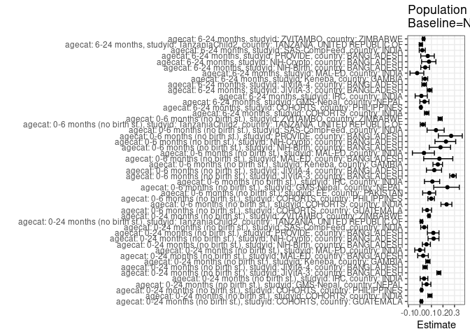

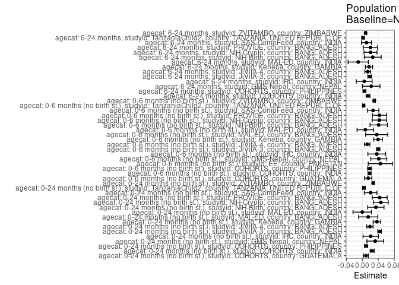

## Results Table

### Parameter: TSM

| agecat | studyid | country | intervention_level | baseline_level | estimate | ci_lower | ci_upper |
| --- | --- | --- | --- | --- | --- | --- | --- |
| 0-24 months (no birth st.) | COHORTS | GUATEMALA | Normal or high birthweight | NA | 0.7052097 | 0.6733356 | 0.7370837 |
| 0-24 months (no birth st.) | COHORTS | GUATEMALA | Low birthweight | NA | 0.8695652 | 0.7721834 | 0.9669470 |
| 0-24 months (no birth st.) | COHORTS | INDIA | Normal or high birthweight | NA | 0.2604046 | 0.2484929 | 0.2723163 |
| 0-24 months (no birth st.) | COHORTS | INDIA | Low birthweight | NA | 0.4449008 | 0.4106779 | 0.4791238 |
| 0-24 months (no birth st.) | COHORTS | PHILIPPINES | Normal or high birthweight | NA | 0.6550397 | 0.6369734 | 0.6731060 |
| 0-24 months (no birth st.) | COHORTS | PHILIPPINES | Low birthweight | NA | 0.8067580 | 0.7500490 | 0.8634669 |
| 0-24 months (no birth st.) | GMS-Nepal | NEPAL | Normal or high birthweight | NA | 0.5291746 | 0.4830762 | 0.5752729 |
| 0-24 months (no birth st.) | GMS-Nepal | NEPAL | Low birthweight | NA | 0.6809867 | 0.5947938 | 0.7671795 |
| 0-24 months (no birth st.) | IRC | INDIA | Normal or high birthweight | NA | 0.5674969 | 0.5119385 | 0.6230553 |
| 0-24 months (no birth st.) | IRC | INDIA | Low birthweight | NA | 0.8043708 | 0.6834065 | 0.9253351 |
| 0-24 months (no birth st.) | JiVitA-3 | BANGLADESH | Normal or high birthweight | NA | 0.2214798 | 0.2129546 | 0.2300051 |
| 0-24 months (no birth st.) | JiVitA-3 | BANGLADESH | Low birthweight | NA | 0.4173809 | 0.3988333 | 0.4359284 |
| 0-24 months (no birth st.) | JiVitA-4 | BANGLADESH | Normal or high birthweight | NA | 0.4089788 | 0.3873289 | 0.4306286 |
| 0-24 months (no birth st.) | JiVitA-4 | BANGLADESH | Low birthweight | NA | 0.5729250 | 0.5069724 | 0.6388776 |
| 0-24 months (no birth st.) | Keneba | GAMBIA | Normal or high birthweight | NA | 0.4937118 | 0.4663100 | 0.5211137 |
| 0-24 months (no birth st.) | Keneba | GAMBIA | Low birthweight | NA | 0.7832204 | 0.7216559 | 0.8447848 |
| 0-24 months (no birth st.) | MAL-ED | BANGLADESH | Normal or high birthweight | NA | 0.5132275 | 0.4418022 | 0.5846528 |
| 0-24 months (no birth st.) | MAL-ED | BANGLADESH | Low birthweight | NA | 0.6400000 | 0.4514023 | 0.8285977 |
| 0-24 months (no birth st.) | MAL-ED | INDIA | Normal or high birthweight | NA | 0.5341869 | 0.4620712 | 0.6063027 |
| 0-24 months (no birth st.) | MAL-ED | INDIA | Low birthweight | NA | 0.4479446 | 0.2323990 | 0.6634903 |
| 0-24 months (no birth st.) | NIH-Birth | BANGLADESH | Normal or high birthweight | NA | 0.5666461 | 0.5185042 | 0.6147879 |
| 0-24 months (no birth st.) | NIH-Birth | BANGLADESH | Low birthweight | NA | 0.7335616 | 0.6468892 | 0.8202339 |
| 0-24 months (no birth st.) | NIH-Crypto | BANGLADESH | Normal or high birthweight | NA | 0.3467021 | 0.3065815 | 0.3868227 |
| 0-24 months (no birth st.) | NIH-Crypto | BANGLADESH | Low birthweight | NA | 0.6095539 | 0.5208383 | 0.6982695 |
| 0-24 months (no birth st.) | PROVIDE | BANGLADESH | Normal or high birthweight | NA | 0.3321166 | 0.2917151 | 0.3725181 |
| 0-24 months (no birth st.) | PROVIDE | BANGLADESH | Low birthweight | NA | 0.5910398 | 0.4978449 | 0.6842346 |
| 0-24 months (no birth st.) | SAS-CompFeed | INDIA | Normal or high birthweight | NA | 0.5451656 | 0.4797301 | 0.6106011 |
| 0-24 months (no birth st.) | SAS-CompFeed | INDIA | Low birthweight | NA | 0.7411289 | 0.6344593 | 0.8477985 |
| 0-24 months (no birth st.) | TanzaniaChild2 | TANZANIA, UNITED REPUBLIC OF | Normal or high birthweight | NA | 0.2945584 | 0.2752814 | 0.3138353 |
| 0-24 months (no birth st.) | TanzaniaChild2 | TANZANIA, UNITED REPUBLIC OF | Low birthweight | NA | 0.4784998 | 0.3512718 | 0.6057277 |

[output cut: 64 more lines]

### Parameter: E(Y)

| agecat | studyid | country | intervention_level | baseline_level | estimate | ci_lower | ci_upper |
| --- | --- | --- | --- | --- | --- | --- | --- |
| 0-24 months (no birth st.) | COHORTS | GUATEMALA | NA | NA | 0.7142857 | 0.6835892 | 0.7449822 |
| 0-24 months (no birth st.) | COHORTS | INDIA | NA | NA | 0.2852591 | 0.2737975 | 0.2967207 |
| 0-24 months (no birth st.) | COHORTS | PHILIPPINES | NA | NA | 0.6646643 | 0.6472674 | 0.6820612 |
| 0-24 months (no birth st.) | GMS-Nepal | NEPAL | NA | NA | 0.5617391 | 0.5211485 | 0.6023298 |
| 0-24 months (no birth st.) | IRC | INDIA | NA | NA | 0.5887324 | 0.5374737 | 0.6399911 |
| 0-24 months (no birth st.) | JiVitA-3 | BANGLADESH | NA | NA | 0.2650737 | 0.2569178 | 0.2732295 |
| 0-24 months (no birth st.) | JiVitA-4 | BANGLADESH | NA | NA | 0.4282588 | 0.4077731 | 0.4487445 |
| 0-24 months (no birth st.) | Keneba | GAMBIA | NA | NA | 0.5305842 | 0.5049322 | 0.5562362 |
| 0-24 months (no birth st.) | MAL-ED | BANGLADESH | NA | NA | 0.5280374 | 0.4609958 | 0.5950790 |
| 0-24 months (no birth st.) | MAL-ED | INDIA | NA | NA | 0.5339806 | 0.4656939 | 0.6022672 |
| 0-24 months (no birth st.) | NIH-Birth | BANGLADESH | NA | NA | 0.6007828 | 0.5582791 | 0.6432864 |
| 0-24 months (no birth st.) | NIH-Crypto | BANGLADESH | NA | NA | 0.3935681 | 0.3560687 | 0.4310676 |
| 0-24 months (no birth st.) | PROVIDE | BANGLADESH | NA | NA | 0.3759874 | 0.3382238 | 0.4137509 |
| 0-24 months (no birth st.) | SAS-CompFeed | INDIA | NA | NA | 0.5661425 | 0.5076572 | 0.6246278 |
| 0-24 months (no birth st.) | TanzaniaChild2 | TANZANIA, UNITED REPUBLIC OF | NA | NA | 0.2985075 | 0.2794291 | 0.3175858 |
| 0-24 months (no birth st.) | ZVITAMBO | ZIMBABWE | NA | NA | 0.3487372 | 0.3403993 | 0.3570750 |
| 0-6 months (no birth st.) | COHORTS | GUATEMALA | NA | NA | 0.2371007 | 0.2078658 | 0.2663357 |
| 0-6 months (no birth st.) | COHORTS | INDIA | NA | NA | 0.0788439 | 0.0719356 | 0.0857521 |
| 0-6 months (no birth st.) | COHORTS | PHILIPPINES | NA | NA | 0.1886926 | 0.1742747 | 0.2031105 |
| 0-6 months (no birth st.) | EE | PAKISTAN | NA | NA | 0.5539906 | 0.4870787 | 0.6209025 |
| 0-6 months (no birth st.) | GMS-Nepal | NEPAL | NA | NA | 0.1739130 | 0.1429052 | 0.2049209 |
| 0-6 months (no birth st.) | IRC | INDIA | NA | NA | 0.3380282 | 0.2887514 | 0.3873050 |
| 0-6 months (no birth st.) | JiVitA-3 | BANGLADESH | NA | NA | 0.1391999 | 0.1330990 | 0.1453008 |
| 0-6 months (no birth st.) | JiVitA-4 | BANGLADESH | NA | NA | 0.0979962 | 0.0852560 | 0.1107365 |
| 0-6 months (no birth st.) | Keneba | GAMBIA | NA | NA | 0.2556701 | 0.2332474 | 0.2780928 |
| 0-6 months (no birth st.) | MAL-ED | BANGLADESH | NA | NA | 0.2149533 | 0.1597864 | 0.2701201 |
| 0-6 months (no birth st.) | MAL-ED | INDIA | NA | NA | 0.2184466 | 0.1618848 | 0.2750084 |
| 0-6 months (no birth st.) | NIH-Birth | BANGLADESH | NA | NA | 0.2309198 | 0.1943452 | 0.2674943 |
| 0-6 months (no birth st.) | NIH-Crypto | BANGLADESH | NA | NA | 0.1898928 | 0.1597870 | 0.2199986 |
| 0-6 months (no birth st.) | PROVIDE | BANGLADESH | NA | NA | 0.1595577 | 0.1310079 | 0.1881074 |
| 0-6 months (no birth st.) | SAS-CompFeed | INDIA | NA | NA | 0.1944444 | 0.1700545 | 0.2188344 |
| 0-6 months (no birth st.) | TanzaniaChild2 | TANZANIA, UNITED REPUBLIC OF | NA | NA | 0.1356852 | 0.1214076 | 0.1499628 |
| 0-6 months (no birth st.) | ZVITAMBO | ZIMBABWE | NA | NA | 0.1716108 | 0.1650114 | 0.1782103 |
| 6-24 months | COHORTS | INDIA | NA | NA | 0.2440256 | 0.2322906 | 0.2557607 |
| 6-24 months | COHORTS | PHILIPPINES | NA | NA | 0.6435738 | 0.6230503 | 0.6640973 |
| 6-24 months | GMS-Nepal | NEPAL | NA | NA | 0.5631313 | 0.5142177 | 0.6120449 |
| 6-24 months | IRC | INDIA | NA | NA | 0.3787234 | 0.3165730 | 0.4408738 |
| 6-24 months | JiVitA-3 | BANGLADESH | NA | NA | 0.2234954 | 0.2132931 | 0.2336976 |
| 6-24 months | JiVitA-4 | BANGLADESH | NA | NA | 0.3682386 | 0.3473666 | 0.3891105 |
| 6-24 months | Keneba | GAMBIA | NA | NA | 0.3827751 | 0.3532908 | 0.4122595 |
| 6-24 months | MAL-ED | INDIA | NA | NA | 0.4276316 | 0.3487215 | 0.5065416 |
| 6-24 months | NIH-Birth | BANGLADESH | NA | NA | 0.5727273 | 0.5192737 | 0.6261808 |
| 6-24 months | NIH-Crypto | BANGLADESH | NA | NA | 0.2628458 | 0.2244546 | 0.3012371 |
| 6-24 months | PROVIDE | BANGLADESH | NA | NA | 0.3004386 | 0.2583143 | 0.3425629 |
| 6-24 months | SAS-CompFeed | INDIA | NA | NA | 0.5018680 | 0.4570583 | 0.5466777 |
| 6-24 months | TanzaniaChild2 | TANZANIA, UNITED REPUBLIC OF | NA | NA | 0.2265576 | 0.2059690 | 0.2471462 |
| 6-24 months | ZVITAMBO | ZIMBABWE | NA | NA | 0.2633691 | 0.2539889 | 0.2727494 |

### Parameter: RR

| agecat | studyid | country | intervention_level | baseline_level | estimate | ci_lower | ci_upper |
| --- | --- | --- | --- | --- | --- | --- | --- |
| 0-24 months (no birth st.) | COHORTS | GUATEMALA | Normal or high birthweight | Normal or high birthweight | 1.0000000 | 1.0000000 | 1.000000 |
| 0-24 months (no birth st.) | COHORTS | GUATEMALA | Low birthweight | Normal or high birthweight | 1.2330591 | 1.0927880 | 1.391336 |
| 0-24 months (no birth st.) | COHORTS | INDIA | Normal or high birthweight | Normal or high birthweight | 1.0000000 | 1.0000000 | 1.000000 |
| 0-24 months (no birth st.) | COHORTS | INDIA | Low birthweight | Normal or high birthweight | 1.7084982 | 1.5631810 | 1.867325 |
| 0-24 months (no birth st.) | COHORTS | PHILIPPINES | Normal or high birthweight | Normal or high birthweight | 1.0000000 | 1.0000000 | 1.000000 |
| 0-24 months (no birth st.) | COHORTS | PHILIPPINES | Low birthweight | Normal or high birthweight | 1.2316168 | 1.1425270 | 1.327654 |
| 0-24 months (no birth st.) | GMS-Nepal | NEPAL | Normal or high birthweight | Normal or high birthweight | 1.0000000 | 1.0000000 | 1.000000 |
| 0-24 months (no birth st.) | GMS-Nepal | NEPAL | Low birthweight | Normal or high birthweight | 1.2868848 | 1.1036871 | 1.500491 |
| 0-24 months (no birth st.) | IRC | INDIA | Normal or high birthweight | Normal or high birthweight | 1.0000000 | 1.0000000 | 1.000000 |
| 0-24 months (no birth st.) | IRC | INDIA | Low birthweight | Normal or high birthweight | 1.4174011 | 1.1844679 | 1.696142 |
| 0-24 months (no birth st.) | JiVitA-3 | BANGLADESH | Normal or high birthweight | Normal or high birthweight | 1.0000000 | 1.0000000 | 1.000000 |
| 0-24 months (no birth st.) | JiVitA-3 | BANGLADESH | Low birthweight | Normal or high birthweight | 1.8845096 | 1.7797526 | 1.995433 |
| 0-24 months (no birth st.) | JiVitA-4 | BANGLADESH | Normal or high birthweight | Normal or high birthweight | 1.0000000 | 1.0000000 | 1.000000 |
| 0-24 months (no birth st.) | JiVitA-4 | BANGLADESH | Low birthweight | Normal or high birthweight | 1.4008674 | 1.2334981 | 1.590946 |
| 0-24 months (no birth st.) | Keneba | GAMBIA | Normal or high birthweight | Normal or high birthweight | 1.0000000 | 1.0000000 | 1.000000 |
| 0-24 months (no birth st.) | Keneba | GAMBIA | Low birthweight | Normal or high birthweight | 1.5863917 | 1.4415121 | 1.745832 |
| 0-24 months (no birth st.) | MAL-ED | BANGLADESH | Normal or high birthweight | Normal or high birthweight | 1.0000000 | 1.0000000 | 1.000000 |
| 0-24 months (no birth st.) | MAL-ED | BANGLADESH | Low birthweight | Normal or high birthweight | 1.2470103 | 0.9001943 | 1.727443 |
| 0-24 months (no birth st.) | MAL-ED | INDIA | Normal or high birthweight | Normal or high birthweight | 1.0000000 | 1.0000000 | 1.000000 |
| 0-24 months (no birth st.) | MAL-ED | INDIA | Low birthweight | Normal or high birthweight | 0.8385541 | 0.5082836 | 1.383426 |
| 0-24 months (no birth st.) | NIH-Birth | BANGLADESH | Normal or high birthweight | Normal or high birthweight | 1.0000000 | 1.0000000 | 1.000000 |
| 0-24 months (no birth st.) | NIH-Birth | BANGLADESH | Low birthweight | Normal or high birthweight | 1.2945674 | 1.1190484 | 1.497616 |
| 0-24 months (no birth st.) | NIH-Crypto | BANGLADESH | Normal or high birthweight | Normal or high birthweight | 1.0000000 | 1.0000000 | 1.000000 |
| 0-24 months (no birth st.) | NIH-Crypto | BANGLADESH | Low birthweight | Normal or high birthweight | 1.7581487 | 1.4609910 | 2.115747 |
| 0-24 months (no birth st.) | PROVIDE | BANGLADESH | Normal or high birthweight | Normal or high birthweight | 1.0000000 | 1.0000000 | 1.000000 |
| 0-24 months (no birth st.) | PROVIDE | BANGLADESH | Low birthweight | Normal or high birthweight | 1.7796153 | 1.4606897 | 2.168175 |
| 0-24 months (no birth st.) | SAS-CompFeed | INDIA | Normal or high birthweight | Normal or high birthweight | 1.0000000 | 1.0000000 | 1.000000 |
| 0-24 months (no birth st.) | SAS-CompFeed | INDIA | Low birthweight | Normal or high birthweight | 1.3594564 | 1.1269558 | 1.639924 |
| 0-24 months (no birth st.) | TanzaniaChild2 | TANZANIA, UNITED REPUBLIC OF | Normal or high birthweight | Normal or high birthweight | 1.0000000 | 1.0000000 | 1.000000 |
| 0-24 months (no birth st.) | TanzaniaChild2 | TANZANIA, UNITED REPUBLIC OF | Low birthweight | Normal or high birthweight | 1.6244651 | 1.2353883 | 2.136079 |

[output cut: 64 more lines]

### Parameter: PAR

| agecat | studyid | country | intervention_level | baseline_level | estimate | ci_lower | ci_upper |
| --- | --- | --- | --- | --- | --- | --- | --- |
| 0-24 months (no birth st.) | COHORTS | GUATEMALA | Normal or high birthweight | NA | 0.0090761 | 0.0028693 | 0.0152828 |
| 0-24 months (no birth st.) | COHORTS | INDIA | Normal or high birthweight | NA | 0.0248545 | 0.0197835 | 0.0299255 |
| 0-24 months (no birth st.) | COHORTS | PHILIPPINES | Normal or high birthweight | NA | 0.0096246 | 0.0056377 | 0.0136115 |
| 0-24 months (no birth st.) | GMS-Nepal | NEPAL | Normal or high birthweight | NA | 0.0325646 | 0.0115500 | 0.0535791 |
| 0-24 months (no birth st.) | IRC | INDIA | Normal or high birthweight | NA | 0.0212355 | 0.0018670 | 0.0406040 |
| 0-24 months (no birth st.) | JiVitA-3 | BANGLADESH | Normal or high birthweight | NA | 0.0435938 | 0.0389896 | 0.0481981 |
| 0-24 months (no birth st.) | JiVitA-4 | BANGLADESH | Normal or high birthweight | NA | 0.0192801 | 0.0113609 | 0.0271992 |
| 0-24 months (no birth st.) | Keneba | GAMBIA | Normal or high birthweight | NA | 0.0368724 | 0.0273504 | 0.0463944 |
| 0-24 months (no birth st.) | MAL-ED | BANGLADESH | Normal or high birthweight | NA | 0.0148099 | -0.0093760 | 0.0389958 |
| 0-24 months (no birth st.) | MAL-ED | INDIA | Normal or high birthweight | NA | -0.0002064 | -0.0234892 | 0.0230764 |
| 0-24 months (no birth st.) | NIH-Birth | BANGLADESH | Normal or high birthweight | NA | 0.0341367 | 0.0135763 | 0.0546970 |
| 0-24 months (no birth st.) | NIH-Crypto | BANGLADESH | Normal or high birthweight | NA | 0.0468660 | 0.0283230 | 0.0654091 |
| 0-24 months (no birth st.) | PROVIDE | BANGLADESH | Normal or high birthweight | NA | 0.0438708 | 0.0250752 | 0.0626664 |
| 0-24 months (no birth st.) | SAS-CompFeed | INDIA | Normal or high birthweight | NA | 0.0209768 | 0.0051172 | 0.0368365 |
| 0-24 months (no birth st.) | TanzaniaChild2 | TANZANIA, UNITED REPUBLIC OF | Normal or high birthweight | NA | 0.0039491 | 0.0006370 | 0.0072612 |
| 0-24 months (no birth st.) | ZVITAMBO | ZIMBABWE | Normal or high birthweight | NA | 0.0273841 | 0.0242946 | 0.0304736 |
| 0-6 months (no birth st.) | COHORTS | GUATEMALA | Normal or high birthweight | NA | 0.0148366 | 0.0055008 | 0.0241724 |
| 0-6 months (no birth st.) | COHORTS | INDIA | Normal or high birthweight | NA | 0.0182449 | 0.0142263 | 0.0222635 |
| 0-6 months (no birth st.) | COHORTS | PHILIPPINES | Normal or high birthweight | NA | 0.0184795 | 0.0130851 | 0.0238739 |
| 0-6 months (no birth st.) | EE | PAKISTAN | Normal or high birthweight | NA | 0.0454192 | 0.0148924 | 0.0759460 |
| 0-6 months (no birth st.) | GMS-Nepal | NEPAL | Normal or high birthweight | NA | 0.0415141 | 0.0214028 | 0.0616255 |
| 0-6 months (no birth st.) | IRC | INDIA | Normal or high birthweight | NA | 0.0364282 | 0.0140849 | 0.0587714 |
| 0-6 months (no birth st.) | JiVitA-3 | BANGLADESH | Normal or high birthweight | NA | 0.0400014 | 0.0358484 | 0.0441543 |
| 0-6 months (no birth st.) | JiVitA-4 | BANGLADESH | Normal or high birthweight | NA | 0.0122248 | 0.0054157 | 0.0190340 |
| 0-6 months (no birth st.) | Keneba | GAMBIA | Normal or high birthweight | NA | 0.0397996 | 0.0289932 | 0.0506060 |
| 0-6 months (no birth st.) | MAL-ED | BANGLADESH | Normal or high birthweight | NA | 0.0362657 | 0.0083560 | 0.0641754 |
| 0-6 months (no birth st.) | MAL-ED | INDIA | Normal or high birthweight | NA | 0.0076358 | -0.0132341 | 0.0285057 |
| 0-6 months (no birth st.) | NIH-Birth | BANGLADESH | Normal or high birthweight | NA | 0.0412874 | 0.0194640 | 0.0631108 |
| 0-6 months (no birth st.) | NIH-Crypto | BANGLADESH | Normal or high birthweight | NA | 0.0428988 | 0.0250250 | 0.0607725 |
| 0-6 months (no birth st.) | PROVIDE | BANGLADESH | Normal or high birthweight | NA | 0.0432494 | 0.0255391 | 0.0609598 |
| 0-6 months (no birth st.) | SAS-CompFeed | INDIA | Normal or high birthweight | NA | 0.0271231 | 0.0125029 | 0.0417432 |
| 0-6 months (no birth st.) | TanzaniaChild2 | TANZANIA, UNITED REPUBLIC OF | Normal or high birthweight | NA | 0.0034192 | 0.0004368 | 0.0064015 |
| 0-6 months (no birth st.) | ZVITAMBO | ZIMBABWE | Normal or high birthweight | NA | 0.0301580 | 0.0269824 | 0.0333336 |
| 6-24 months | COHORTS | INDIA | Normal or high birthweight | NA | 0.0143506 | 0.0095880 | 0.0191133 |
| 6-24 months | COHORTS | PHILIPPINES | Normal or high birthweight | NA | 0.0054596 | 0.0017403 | 0.0091789 |
| 6-24 months | GMS-Nepal | NEPAL | Normal or high birthweight | NA | 0.0224516 | 0.0004321 | 0.0444711 |
| 6-24 months | IRC | INDIA | Normal or high birthweight | NA | 0.0048916 | -0.0150324 | 0.0248157 |
| 6-24 months | JiVitA-3 | BANGLADESH | Normal or high birthweight | NA | 0.0187107 | 0.0139737 | 0.0234477 |
| 6-24 months | JiVitA-4 | BANGLADESH | Normal or high birthweight | NA | 0.0136144 | 0.0063326 | 0.0208962 |
| 6-24 months | Keneba | GAMBIA | Normal or high birthweight | NA | 0.0168554 | 0.0077255 | 0.0259853 |
| 6-24 months | MAL-ED | INDIA | Normal or high birthweight | NA | -0.0103246 | -0.0358261 | 0.0151769 |
| 6-24 months | NIH-Birth | BANGLADESH | Normal or high birthweight | NA | 0.0263455 | 0.0051190 | 0.0475720 |
| 6-24 months | NIH-Crypto | BANGLADESH | Normal or high birthweight | NA | 0.0207028 | 0.0043628 | 0.0370428 |
| 6-24 months | PROVIDE | BANGLADESH | Normal or high birthweight | NA | 0.0204778 | 0.0028505 | 0.0381051 |
| 6-24 months | SAS-CompFeed | INDIA | Normal or high birthweight | NA | 0.0104277 | -0.0021845 | 0.0230398 |
| 6-24 months | TanzaniaChild2 | TANZANIA, UNITED REPUBLIC OF | Normal or high birthweight | NA | 0.0018457 | -0.0012981 | 0.0049895 |
| 6-24 months | ZVITAMBO | ZIMBABWE | Normal or high birthweight | NA | 0.0083532 | 0.0058195 | 0.0108868 |

### Parameter: PAF

| agecat | studyid | country | intervention_level | baseline_level | estimate | ci_lower | ci_upper |
| --- | --- | --- | --- | --- | --- | --- | --- |
| 0-24 months (no birth st.) | COHORTS | GUATEMALA | Normal or high birthweight | NA | 0.0127065 | 0.0039108 | 0.0214245 |
| 0-24 months (no birth st.) | COHORTS | INDIA | Normal or high birthweight | NA | 0.0871295 | 0.0692940 | 0.1046232 |
| 0-24 months (no birth st.) | COHORTS | PHILIPPINES | Normal or high birthweight | NA | 0.0144804 | 0.0084302 | 0.0204936 |
| 0-24 months (no birth st.) | GMS-Nepal | NEPAL | Normal or high birthweight | NA | 0.0579710 | 0.0194742 | 0.0949563 |
| 0-24 months (no birth st.) | IRC | INDIA | Normal or high birthweight | NA | 0.0360698 | 0.0023117 | 0.0686857 |
| 0-24 months (no birth st.) | JiVitA-3 | BANGLADESH | Normal or high birthweight | NA | 0.1644593 | 0.1471919 | 0.1813770 |
| 0-24 months (no birth st.) | JiVitA-4 | BANGLADESH | Normal or high birthweight | NA | 0.0450196 | 0.0263125 | 0.0633673 |
| 0-24 months (no birth st.) | Keneba | GAMBIA | Normal or high birthweight | NA | 0.0694939 | 0.0510406 | 0.0875883 |
| 0-24 months (no birth st.) | MAL-ED | BANGLADESH | Normal or high birthweight | NA | 0.0280470 | -0.0190229 | 0.0729427 |
| 0-24 months (no birth st.) | MAL-ED | INDIA | Normal or high birthweight | NA | -0.0003865 | -0.0449530 | 0.0422794 |
| 0-24 months (no birth st.) | NIH-Birth | BANGLADESH | Normal or high birthweight | NA | 0.0568204 | 0.0215166 | 0.0908504 |
| 0-24 months (no birth st.) | NIH-Crypto | BANGLADESH | Normal or high birthweight | NA | 0.1190799 | 0.0704496 | 0.1651660 |
| 0-24 months (no birth st.) | PROVIDE | BANGLADESH | Normal or high birthweight | NA | 0.1166815 | 0.0650814 | 0.1654337 |
| 0-24 months (no birth st.) | SAS-CompFeed | INDIA | Normal or high birthweight | NA | 0.0370522 | 0.0071018 | 0.0660992 |
| 0-24 months (no birth st.) | TanzaniaChild2 | TANZANIA, UNITED REPUBLIC OF | Normal or high birthweight | NA | 0.0132295 | 0.0020614 | 0.0242726 |
| 0-24 months (no birth st.) | ZVITAMBO | ZIMBABWE | Normal or high birthweight | NA | 0.0785235 | 0.0696223 | 0.0873396 |
| 0-6 months (no birth st.) | COHORTS | GUATEMALA | Normal or high birthweight | NA | 0.0625751 | 0.0226760 | 0.1008452 |
| 0-6 months (no birth st.) | COHORTS | INDIA | Normal or high birthweight | NA | 0.2314055 | 0.1826124 | 0.2772860 |
| 0-6 months (no birth st.) | COHORTS | PHILIPPINES | Normal or high birthweight | NA | 0.0979346 | 0.0694825 | 0.1255167 |
| 0-6 months (no birth st.) | EE | PAKISTAN | Normal or high birthweight | NA | 0.0819855 | 0.0239964 | 0.1365292 |
| 0-6 months (no birth st.) | GMS-Nepal | NEPAL | Normal or high birthweight | NA | 0.2387064 | 0.1197211 | 0.3416087 |
| 0-6 months (no birth st.) | IRC | INDIA | Normal or high birthweight | NA | 0.1077667 | 0.0392344 | 0.1714106 |
| 0-6 months (no birth st.) | JiVitA-3 | BANGLADESH | Normal or high birthweight | NA | 0.2873663 | 0.2587568 | 0.3148715 |
| 0-6 months (no birth st.) | JiVitA-4 | BANGLADESH | Normal or high birthweight | NA | 0.1247480 | 0.0565849 | 0.1879862 |
| 0-6 months (no birth st.) | Keneba | GAMBIA | Normal or high birthweight | NA | 0.1556677 | 0.1132744 | 0.1960342 |
| 0-6 months (no birth st.) | MAL-ED | BANGLADESH | Normal or high birthweight | NA | 0.1687143 | 0.0330475 | 0.2853465 |
| 0-6 months (no birth st.) | MAL-ED | INDIA | Normal or high birthweight | NA | 0.0349550 | -0.0652535 | 0.1257368 |
| 0-6 months (no birth st.) | NIH-Birth | BANGLADESH | Normal or high birthweight | NA | 0.1787956 | 0.0815747 | 0.2657251 |
| 0-6 months (no birth st.) | NIH-Crypto | BANGLADESH | Normal or high birthweight | NA | 0.2259104 | 0.1307195 | 0.3106774 |
| 0-6 months (no birth st.) | PROVIDE | BANGLADESH | Normal or high birthweight | NA | 0.2710583 | 0.1599035 | 0.3675061 |
| 0-6 months (no birth st.) | SAS-CompFeed | INDIA | Normal or high birthweight | NA | 0.1394901 | 0.0619753 | 0.2105995 |
| 0-6 months (no birth st.) | TanzaniaChild2 | TANZANIA, UNITED REPUBLIC OF | Normal or high birthweight | NA | 0.0251992 | 0.0030291 | 0.0468762 |
| 0-6 months (no birth st.) | ZVITAMBO | ZIMBABWE | Normal or high birthweight | NA | 0.1757347 | 0.1578542 | 0.1932356 |
| 6-24 months | COHORTS | INDIA | Normal or high birthweight | NA | 0.0588079 | 0.0391876 | 0.0780276 |
| 6-24 months | COHORTS | PHILIPPINES | Normal or high birthweight | NA | 0.0084832 | 0.0026707 | 0.0142619 |
| 6-24 months | GMS-Nepal | NEPAL | Normal or high birthweight | NA | 0.0398693 | -0.0002498 | 0.0783791 |
| 6-24 months | IRC | INDIA | Normal or high birthweight | NA | 0.0129161 | -0.0411287 | 0.0641554 |
| 6-24 months | JiVitA-3 | BANGLADESH | Normal or high birthweight | NA | 0.0837185 | 0.0626475 | 0.1043158 |
| 6-24 months | JiVitA-4 | BANGLADESH | Normal or high birthweight | NA | 0.0369716 | 0.0169706 | 0.0565656 |
| 6-24 months | Keneba | GAMBIA | Normal or high birthweight | NA | 0.0440348 | 0.0198274 | 0.0676444 |
| 6-24 months | MAL-ED | INDIA | Normal or high birthweight | NA | -0.0241437 | -0.0856419 | 0.0338708 |
| 6-24 months | NIH-Birth | BANGLADESH | Normal or high birthweight | NA | 0.0460001 | 0.0078243 | 0.0827070 |
| 6-24 months | NIH-Crypto | BANGLADESH | Normal or high birthweight | NA | 0.0787641 | 0.0147293 | 0.1386371 |
| 6-24 months | PROVIDE | BANGLADESH | Normal or high birthweight | NA | 0.0681597 | 0.0077651 | 0.1248782 |
| 6-24 months | SAS-CompFeed | INDIA | Normal or high birthweight | NA | 0.0207777 | -0.0056956 | 0.0465541 |
| 6-24 months | TanzaniaChild2 | TANZANIA, UNITED REPUBLIC OF | Normal or high birthweight | NA | 0.0081466 | -0.0058589 | 0.0219571 |
| 6-24 months | ZVITAMBO | ZIMBABWE | Normal or high birthweight | NA | 0.0317166 | 0.0220674 | 0.0412705 |